# Final Project

## Andrew Singh

### 12/3/2024

#### Q1

#### Read in the data, call the dataframe "s" and check the dimensions of the dataframe.

```python
import pandas as pd
import numpy as np
import matplotlib.pyplot as plt
import seaborn as sns
from sklearn.linear_model import LogisticRegression
from sklearn.model_selection import train_test_split
from sklearn.metrics import classification_report
from sklearn.metrics import confusion_matrix
from sklearn.preprocessing import LabelEncoder
from sklearn.metrics import accuracy_score
import streamlit as st
```

```python
s = pd.read_csv("social_media_usage.csv")
```

```python
print(s.head())
```

```
   respid  sample  comp   int_date  lang  state  density usr qs1  sex  ...  \
0     798       1     1  1/26/2021     1     51        5   S        2  ...
1    1017       1     1  1/25/2021     1     39        2   S        1  ...
2    1181       1     1  1/25/2021     1     32        2   U        2  ...
3    1388       1     1  1/25/2021     1      4        3   U        1  ...
4    1664       1     1  1/26/2021     1     12        2   S        2  ...

   income  party partyln  hh1  hh3 ql1 ql1a qc1    weight cellweight
0       6      2            1        1           0.557187
1       5      1            2    2   1           0.987209
2       8      3       2    2    2   1           0.925147
3       8      2            1        1           0.311080
4       7      2            2    2   1           0.396548

[5 rows x 89 columns]
```

```python
print("Dimensions of the dataframe:", s.shape)
```

```
Dimensions of the dataframe: (1502, 89)
```

The dimensions of the dataframe contains 1,502 rows and 89 columns of data.

#### Q2

#### Define a function called clean_sm that takes one input, x, and uses `np.where` to check whether x is equal to 1. If it is, make the value of x = 1, otherwise make it 0. Return x. Create a toy dataframe with three rows and two columns and test your function to make sure it works as expected

```python
def clean_sm(x):
    return np.where(x == 1, 1, 0)
```

```python
toy_df = {'income': [1,2,3],
          'marital': [1,3,3]}

toy_df = pd.DataFrame(toy_df)

print(toy_df)
```

```
   income  marital
0       1        1
1       2        3
2       3        3
```

```python
clean_sm(toy_df)
```

```
array([[1, 1],
       [0, 0],
       [0, 0]])
```

#### Q3

#### Create a new dataframe called "ss". The new dataframe should contain a target column called sm_li which should be a binary variable ( that takes the value of 1 if it is 1 and 0 otherwise (use clean_sm to create this) which indicates whether or not the individual uses LinkedIn, and the following features: income (ordered numeric from 1 to 9, above 9 considered missing), education (ordered numeric from 1 to 8, above 8 considered missing), parent (binary), married (binary), female (binary), and age (numeric, above 98 considered missing). Drop any missing values. Perform exploratory analysis to examine how the features are related to the target.

```python
ss = s[['web1h', 'income', 'educ2', 'par', 'marital', 'gender', 'age']].copy()
```

```python
ss.rename(columns={
    'web1h': 'sm_li',
    'educ2': 'education',
    'par': 'parent',
    'marital': 'married',
    'gender': 'female'
}, inplace=True)
```

```python
ss['sm_li'] = ss['sm_li'].apply(clean_sm)
```

```python
ss['female'] = ss['female'].apply(lambda x: 1 if x == 2 else 0)
```

```python
ss = ss[(ss['income'] <= 9) & (ss['education'] <= 8) & (ss['age'] <= 98)].dropna()
```

```python
print("Cleaned DataFrame:\n", ss.head())
```

```
Cleaned DataFrame:
    sm_li  income  education  parent  married  female  age
0      0       6          4       2        5       1   77
1      0       5          3       2        6       0   59
2      0       8          4       2        1       1   60
3      0       8          8       2        6       0   73
4      1       7          8       2        1       1   65
```

```python
ss.dropna(inplace=True)
```

```python
print(ss.head())
```

```
   sm_li  income  education  parent  married  female  age
0      0       6          4       2        5       1   77
1      0       5          3       2        6       0   59
2      0       8          4       2        1       1   60
3      0       8          8       2        6       0   73
4      1       7          8       2        1       1   65
```

```python
print(ss.info())
```

```
<class 'pandas.core.frame.DataFrame'>
Index: 1260 entries, 0 to 1501
Data columns (total 7 columns):
 #   Column     Non-Null Count  Dtype
---  ------     --------------  -----
 0   sm_li      1260 non-null   int64
 1   income     1260 non-null   int64
 2   education  1260 non-null   int64
 3   parent     1260 non-null   int64
 4   married    1260 non-null   int64
 5   female     1260 non-null   int64
 6   age        1260 non-null   int64
dtypes: int64(7)
memory usage: 78.8 KB
None
```

```python
# perform summary analysis on the ss dataframe
print(ss.describe())
```

```
             sm_li       income    education       parent      married  \
count  1260.000000  1260.000000  1260.000000  1260.000000  1260.000000
mean      0.333333     5.865873     5.203175     1.750794     2.773810
std       0.471592     2.474385     1.877501     0.432725     2.086024
min       0.000000     1.000000     1.000000     1.000000     1.000000
25%       0.000000     4.000000     4.000000     2.000000     1.000000
50%       0.000000     6.000000     5.000000     2.000000     2.000000
75%       1.000000     8.000000     6.000000     2.000000     5.000000
max       1.000000     9.000000     8.000000     2.000000     9.000000

            female          age
count  1260.000000  1260.000000
mean      0.419841    51.253968
std       0.493729    18.403705
min       0.000000    18.000000
25%       0.000000    36.000000
50%       0.000000    52.000000
75%       1.000000    65.000000
max       1.000000    97.000000
```

```python
# plot a correlation
correlation_matrix = ss.corr()
print(correlation_matrix)
```

```
              sm_li    income  education    parent   married    female  \
sm_li      1.000000  0.329674   0.310088 -0.102495 -0.079933 -0.076186
income     0.329674  1.000000   0.438773 -0.093554 -0.339344 -0.098204
education  0.310088  0.438773   1.000000 -0.037349 -0.174836  0.052714
parent    -0.102495 -0.093554  -0.037349  1.000000  0.268354 -0.034091
married   -0.079933 -0.339344  -0.174836  0.268354  1.000000  0.017471
female    -0.076186 -0.098204   0.052714 -0.034091  0.017471  1.000000
age       -0.159209  0.022394   0.111718  0.263081 -0.241004  0.096999

                age
sm_li     -0.159209
income     0.022394
education  0.111718
parent     0.263081
married   -0.241004
female     0.096999
age        1.000000
```

Based on the correlation matrix, the predictor variables are related to the target variable in that income and edcuation are somewhat strongly positively correlated with the sm_li. The predictor variables that are not strongly correlated and are negatively correlated are parent, married, age and female with those being LinkedIn users or not.

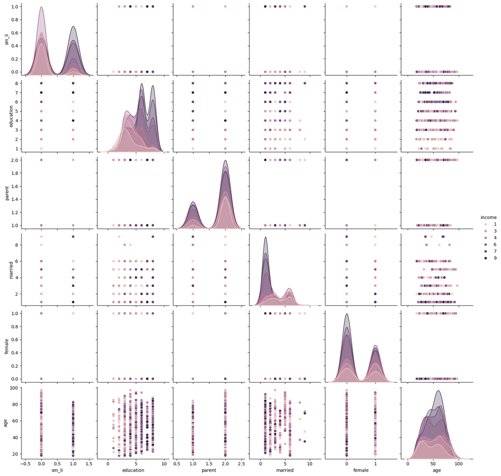

```python
sns.pairplot(ss, hue='income')
plt.show()
```

From this pairplot focused on the distribution of income, we find that the highest amount of values in the sm_li box when separated by income level, majority of the users who are not LinkedIn users are in the third income group/bracket earning between $20,000 to $30,000 per year. While those who are LinkedIn users are earning a higher annual salary per year than their counterparts.

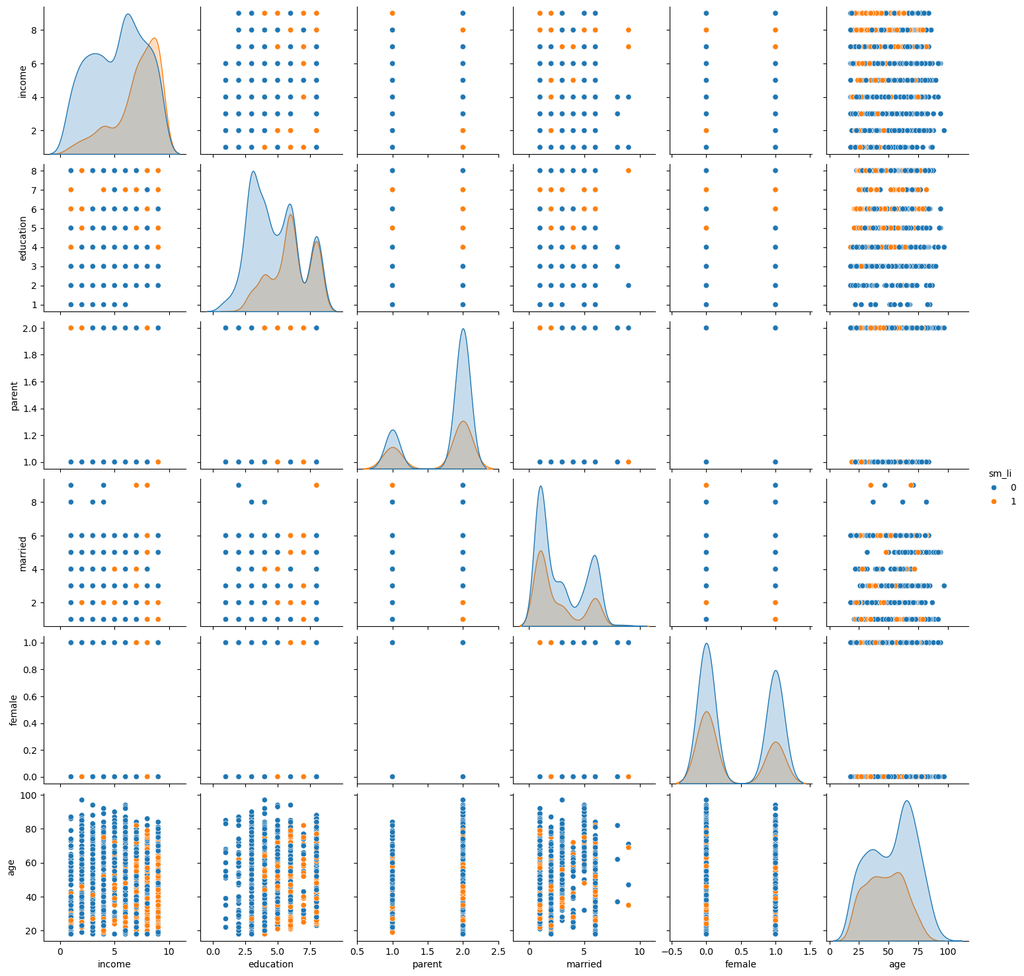

```python
sns.pairplot(ss, hue='sm_li')
plt.show()
```

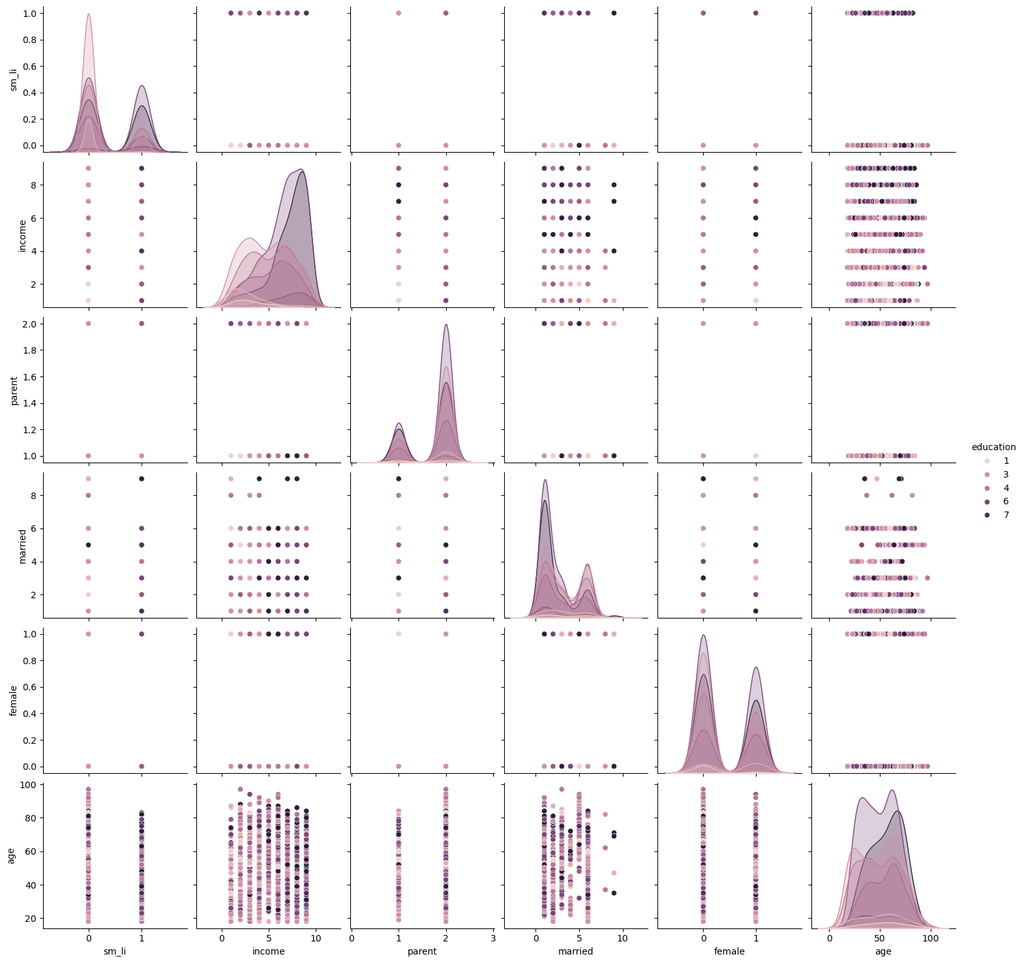

```python
sns.pairplot(ss, hue='education')
plt.show()
```

#### Q4

#### Create a target vector (y) and feature set (X)

```python
ss_df = ss
```

```python
ss_df = ss_df.drop("sm_li", axis = 1)
```

```python
# Define the target vector (y) and feature set (X)
y = ss['sm_li']  # Target vector
X = ss.drop(columns=['sm_li'])  # Feature set

# Check the shapes of X and y
print(f"Feature set shape: {X.shape}")
print(f"Target vector shape: {y.shape}")
```

```
Feature set shape: (1260, 6)
Target vector shape: (1260,)
```

#### Q5

#### Split the data into training and test sets. Hold out 20% of the data for testing. Explain what each new object contains and how it is used in machine learning.

```python
# Split the data into training and test sets
X_train, X_test, y_train, y_test = train_test_split(X.values,
                                                    y,
                                                    stratify = y,
                                                    test_size=0.2,
                                                    random_state=42)

# Print the shapes of the resulting datasets
print(f"X_train shape: {X_train.shape}")
print(f"X_test shape: {X_test.shape}")
print(f"y_train shape: {y_train.shape}")
print(f"y_test shape: {y_test.shape}")
```

```
X_train shape: (1008, 6)
X_test shape: (252, 6)
y_train shape: (1008,)
y_test shape: (252,)
```

Each new object in the model serves a purpose in the machine learning model for this project.

X_train contains the feature values we will use for the independent variables in the training dataset. X_train is used in the machine learning model by training the data to learn new patterns between the features and target variable of interest. In this case, X_train contains 80% of the data and contains the features used to predict the target when training the model.

X_test contains the portion of the dataset that is not used for training the features component of the dataset, it is used to perform predictions based on our training data. It is used to help compare the predictability of the model compared to Y_test to see how well the model generalizes test data. In this case, X_test contains 20% of the data and contains the features used to test the model on unseen data to evaluate performance.

Y_train holds the target values for the dependent variable in the dataset. Y_train is used in training the machine learning algorithm, while supporting a more precise fit between the predictions the model makes and the realistic values in the Y_train dataset. In this case, y_train contains 80% of the data and contains the target that we will predict using the features when training the model.

Y_test holds the values for the testing set, this is the portion of the dataset that was not used for training. Y_test is used to make comparison predictions based on the independent values held in X_test to make sure the predictions are not far off. The Y_test data is used to calculate metrics related to evaluating the efficacy of the machine learning model by outputting the precision, recall, and other values. In this case, Y_test contains 20% of the data and contains the target we will predict when testing the model on unseen data to evaluate performance.

#### Q6

#### Instantiate a logistic regression model and set class_weight to balanced. Fit the model with the training data.

```python
# Define and fit the logistic regression model
logistic_model = LogisticRegression(class_weight='balanced', random_state=42)
logistic_model.fit(X_train, y_train)
```

```
LogisticRegression(class_weight='balanced', random_state=42)
```

#### Q7

#### Evaluate the model using the testing data. What is the model accuracy for the model? Use the model to make predictions and then generate a confusion matrix from the model. Interpret the confusion matrix and explain what each number means.

```python
# Evaluate the model
y_pred = logistic_model.predict(X_test)
accuracy = accuracy_score(y_test, y_pred)
print(f"Model Accuracy: {accuracy:.2f}")
```

```
Model Accuracy: 0.63
```

The model accuracy is 0.63.

```python
pd.DataFrame(confusion_matrix(y_test, y_pred),
            columns=["Predicted negative", "Predicted positive"],
            index=["Actual negative","Actual positive"]).style.background_gradient(cmap="PiYG")
```

|  | Predicted negative | Predicted positive |
| --- | --- | --- |
| Actual negative | 103 | 65 |
| Actual positive | 27 | 57 |

The accuracy of the model is .63.

In the upper left quadrant, the model correctly predicted that 103 individuals as not being LinkedIn users. In the bottom left quadrant, the model incorrectly predicted 27 LinkedIn users as not users. In the upper right quadrant, the model incorrectly predicted 65 individuals as LinkedIn users when they are not. In the bottom right quadrant, the model correctly identified 57 individuals as LinkedIn users.

#### Q8

#### Create the confusion matrix as a dataframe and add informative column names and index names that indicate what each quadrant represents

```python
# Create a DataFrame with informative labels
pd.DataFrame(confusion_matrix(y_test, y_pred),
            columns=["Predicted negative", "Predicted positive"],
            index=["Actual negative","Actual positive"]).style.background_gradient(cmap="PiYG")
```

|  | Predicted negative | Predicted positive |
| --- | --- | --- |
| Actual negative | 103 | 65 |
| Actual positive | 27 | 57 |

#### Q9

#### Aside from accuracy, there are three other metrics used to evaluate model performance: precision, recall, and F1 score. Use the results in the confusion matrix to calculate each of these metrics by hand. Discuss each metric and give an actual example of when it might be the preferred metric of evaluation. After calculating the metrics by hand, create a classification_report using sklearn and check to ensure your metrics match those of the classification_report.

```python
# Assuming y_test and y_pred are defined
print(classification_report(y_test, y_pred))
```

```
              precision    recall  f1-score   support

           0       0.79      0.61      0.69       168
           1       0.47      0.68      0.55        84

    accuracy                           0.63       252
   macro avg       0.63      0.65      0.62       252
weighted avg       0.68      0.63      0.65       252
```

Accuracy measures the correct number of cases that were identified out of the entire sample. It evaluates how well a model performs overall by comparison of its predicted values to the actual outcomes. An example of this is used to evaluate the efficacy of a model when predicting the number of patients that correctly have a disease out of the entire sample group in a clinical trial.

Precision is used as a performance metric when the goal is to limit the number of false positives. An example of precision is using a model duirng a clinical trial that is used to see whether a drug is effective in treating a disease, lets say for example cancer. As trials are very expensive to run and operate the research and development arm of a biotech company might want to run the experiment only if the experiment has a high likelihood of success. This allows the drug to be tested, while in testing the model should not produce as many false positives, it is important that as a result the trial has a high rate of precision or positive predictive value.

Recall is measuring how many of the positive samples are captured by the positive predictions. Recall is used as performance metric when we need to identify all positive samples; that is, when it is important to avoid false negatives. An example of when this metric might be the preferred metric for evaluation is when we want to find all the people in a certain trial to be sick, sometimes we may want to find all the patients that are sick and categorize them as positive for a certain disease. In the search for patients that are sick with a certain disease we may categorize those that are not sick as positive for a disease. Even though, this conclusion is false that not all patients are sick, we run the risk of including many false positives in the search for finding patients that are sick. This may damage our recall or sensitivity percentage.

The F1 score is used to receive the full picture of the situation that combines the precision and recall into one metric. As it takes into account recall and precision, the F1 score provides a better measure than accuracy on imbalanced binary classification datasets. An example of the F1 score being used is when the clinical research team wants to evaluate whether or not a certain patient has a disease or not as the F1 score evaluates the performance of their clinical model being used, they would want to know how many of the correct patient cases are identified as positive cases in this case, the recall metric, and how many are false positives, the precision metric.

When calculating the performance metrics by hand, the metrics are equalivant to the produced metrics from the classification report. Metric calculations by are below.

Precision = TP / (TP + FP) = 57 / (57 + 65) = .0.4672 (approx. equal to .47)

Recall = TP / (TP + FN)= 57 / (57 + 27) = .6786 (approx. equal to .68)

F1 Score = 2 * (Precision * Recall) / (Precision + Recall) = 2 * (.4672 * .6786) / (.4672 + .6786) = .5516 (approx. equal to .55)

#### Q10

#### Use the model to make predictions. For instance, what is the probability that a high income (e.g. income=8), with a high level of education (e.g. 7), non-parent who is married female and 42 years old uses LinkedIn? How does the probability change if another person is 82 years old, but otherwise the same?

```python
newdata = pd.DataFrame({
    "income":[8,8],
    "education": [7,7],
    "parent": [0,0],
    "married":[1,1],
    "female":[0,0],
    "age":[42,82]
})
```

```python
newdata
```

|  | income | education | parent | married | female | age |
| --- | --- | --- | --- | --- | --- | --- |
| 0 | 8 | 7 | 0 | 1 | 0 | 42 |
| 1 | 8 | 7 | 0 | 1 | 0 | 82 |

```python
newdata["prediction_pro"]=logistic_model.predict(newdata)
```

```python
newdata
```

|  | income | education | parent | married | female | age | prediction_pro |
| --- | --- | --- | --- | --- | --- | --- | --- |
| 0 | 8 | 7 | 0 | 1 | 0 | 42 | 1 |
| 1 | 8 | 7 | 0 | 1 | 0 | 82 | 1 |

```python
person1 = [8,7,0,1,0,42]
person2 = [8,7,0,1,0,82]
```

```python
# Predict class, given input features
predicted_class1 = logistic_model.predict([person1])
predicted_class2 = logistic_model.predict([person2])

# Generate probability of positive class (=1)
probs1 = logistic_model.predict_proba([person1])
probs2 = logistic_model.predict_proba([person2])
```

```python
# Print predicted class and probability
print(f"Predicted class1: {predicted_class1[0]}")
print(f"Probability of LinkedIn usage (42 year old female): {probs1[0][1]}")
```

```
Predicted class1: 1
Probability of LinkedIn usage (42 year old female): 0.8362532449214737
```

```python
print(f"Predicted class: {predicted_class2[0]}")
print(f"Probability of LinkedIn usage (82 year old female): {probs2[0][1]}")
```

```
Predicted class: 1
Probability of LinkedIn usage (82 year old female): 0.6143579216949169
```

How does the probability change if another person is 82 years old, but otherwise the same? The probability drops to 61.43%.

#### Streamlit Application

This document contains the direct user link to my LinkedIn Prediction Model Application.

https://linkedinpredictionapp.streamlit.app/